# Chapter 10: Data Integration into Physical Models

**Goals**

- Understand the necessity for model calibration
- Learn how to fit model parameters to experiments
- Combine all previously learned topics in a single application example

## 10.1 Introduction

In chapter 9, we solved the simplified ODE for the coffee extraction kinetics:

$$ \frac{\mathrm{d}c}{\mathrm{d}t}=k(c_{\infty}-c) \quad \quad \quad (1)$$

The kinetic parameters $k$ and $c_{\infty}$ are decisive. So far, we assumed that we **know** their values, which is far from true. For example, the parameter $k$ depends on various factors like coffee grind size, water temperature, pressure, coffee brand and so on. These dependencies $k=f(T,p,..)$ are often non-linear, but most importantly **unknown**. For some parameters we may have a physical model, like an Arrhenius-type equation for $k=f(T)$ due to the dominance of the diffusion processes. However, in general this is not the case! (Try your luck finding an analytical expression for $k=f(\textrm{coffee brand})$.)

To put this in perspective, modeling a physical process requires the following three steps:

1. **Set up** the (physical) model equations (ODEs).  
   $\rightarrow$ Not covered in this course. But you might want to take a look at [digitalization in particle technology](https://www.mvm.kit.edu/lehre_vm_5613.php).
2. **Solve** the ODE (numerically if necessary). $\rightarrow$ This was the subject of chapter 9.
3. **Calibrate** the model, i.e. find the kinetic parameters and functional relations for them.  
   $\rightarrow$ This is the topic of today's lecture.

All three of these steps are necessary for a successful model! Depending on the actual physical process (extraction, sedimentation, agglomeration, ...), these steps will vary in the amount of relative effort they require.  
An example: In computational fluid dynamics (CFD), the [Navier-Stokes equations](https://en.wikipedia.org/wiki/Navier%E2%80%93Stokes_equations) and *"kinetic"* parameters ($\rho$, $\eta$, ..) are known. The challenge lies in solving the equations, which requires sophisticated discretization schemes and numerical solvers. In our coffee example, both the ODE and the solution are straightforward. However, the kinetic rates $k$ and $c_{\infty}$ are the bottleneck for accurate results.

## 10.2 Estimating $k$ and $c_{\infty}$ from an Experiment

## 10.2.1 The General Concept

Funny enough, today we will not be learning any new skills or numerical tools, but rather applying and combining what we learned in chapters 5-9. The situation is quite simple: We have experimental data on the coffee extraction kinetics $c_{\mathrm{exp}}(t)$ and our ODE in Eq. (1). We already know how to solve this initial value problem to obtain $c_{\mathrm{mod}}(t)$. Therefore, the task at hand can be formulated as follows:

*Find the kinetic parameters $k$ and $c_{\infty}$ for which the solution of the physical model in Eq. (1) best fits the experimental observations.*

Well, that sounds like an optimization problem! In mathematical terms, we can rephrase the problem as

$$ \min_{k, c_{\infty}}\quad \Delta\left(c_{\mathrm{exp}}(t), c_{\mathrm{mod}}(t)\right) \quad \quad \quad (2)$$

## 10.2.2 Implementation in Python

We now combine everything that we have learned so far to estimate the coffee extraction kinetic parameters `k` and `c_inf` from raw experimental UV-VIS data. This sounds like a lot (because it is), but understanding this workflow will hopefully give you an appreciation for the larger goal we have been working towards over the past few weeks. In addition, this procedure is generic in the sense that it can be applied to a variety of physical problems where kinetic rates need to be estimated from experimental data.

**Import and evaluate experimental raw data**

Let's assume that we have a trained linear regression model `lin_mod` that is able to predict the caffeine concentration from an absorbance spectrum $c=f(A)$ (see chapter 7). We now define a function `imp_exp(folder, mod)` that takes a folder path as `str` containing raw experimental UV-vis data from an extraction experiment and a trained regression model `mod`. This function imports said data and transforms it into $c_{\mathrm{exp}}(t)$ (see chapter 7).

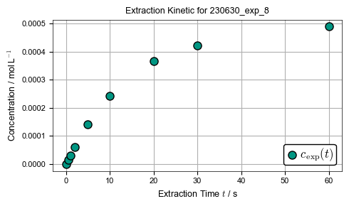

```python
import numpy as np
import os
import matplotlib.pyplot as plt
from mod.import_functions import read_exp_folder
import mod.my_plotter as mp
mp.init_plot(scl_a4=1, page_lnewdth_cm=10, mrksze=8)

# Import all raw data inside folder and return the mean kinetic c(t) over all repetitions
def imp_exp(folder, mod):
    # Find the number of repetitions in the experimental folder
    filenames = os.listdir(folder)

    reps = np.ones((len(filenames)))
    for i in range(len(filenames)):
        reps[i] = filenames[i].split('_')[-1].split('.')[0]
    reps = list(np.unique(reps).astype(int))

    # Initialize c-array to store repetition results. Import an experiment to know t.
    _, _, t = read_exp_folder(folder, rep=1)
    c_reps = np.zeros((len(t),len(reps)))

    # Loop through all repetitions and calculate the kinetic.
    for r in range(len(reps)):
        # Import absorbance array
        _, A, _ = read_exp_folder(folder, rep=reps[r])

        # Predict concentration
        c_reps[:,r] = mod.predict(A)

    # Calculate and return mean extraction kinetic
    c_mean = np.mean(c_reps, axis=1)

    return t, c_mean

### MAIN part of the script
# Parameter definitions
folder = './data/exp_data/230630_exp_8/'
exp_name = folder.split('/')[-2]

# Import OLS model from chapter 7
lin_mod = np.load('./data/my_ols_model.npy', allow_pickle=True).item()

# Import UV-VIS data and transform into experimental extraction kinetic
t_exp, c_exp = imp_exp(folder, lin_mod)

# Plot results and make pretty.
fig, ax = plt.subplots(figsize=(5,3))
ax.scatter(t_exp, c_exp, edgecolors='black', color=mp.green, label='$c_{\,\mathrm{exp}}(t)$')
ax.set_ylabel('Concentration / mol$\,$L$^{-1}$')
ax.set_xlabel('Extraction Time $t$ / s')
ax.legend(loc='lower right', fontsize='large', framealpha=1, ncol=1, labelspacing = 0.6)
ax.grid(True)
ax.set_title(f'Extraction Kinetic for {exp_name}')
plt.tight_layout()
```

**Setting up a cost function**

Let's set up a **cost function** for the optimization problem in Eq. (2). This function must be suitable for later use with optimization algorithms from the `scipy` package. This means that all parameters for which we want to optimize are passed as an array (here our kinetic rates `k` and `c_inf`). All other arguments, like the experimental extraction kinetics (`c_exp`, `t_exp`), should be passed via the `*args` keyword (see chapter 6).

The cost function calculates the numerical solution of Eq. (1) for the provided values of `k` and `c_inf` and stores it at the discrete time points of the experiment `t_exp`. This is done with `scipy.solve_ivp( )` and was discussed in chapter 9.

Subsequently, a residual $\Delta$ between the experiment and the model is calculated and returned. In this example we'll use the **r**oot **m**ean **s**quared **e**rror (RMSE).

```python
from scipy.integrate import solve_ivp

# RHS function of Eq. (1)
def rhs_kinetic(t, y, k, c_inf):
    dydt = k*(c_inf-y)
    return dydt

# Set-up the cost function for evaluation
def cost_fun_extraction(opt_param, *args):
    # Extract optimization parameters for readability
    k = opt_param[0]
    c_inf = opt_param[1]

    # Extract *args for readability
    c_exp = args[0]
    t_exp = args[1]

    # Calculate c_mod(t) with provided k and c_inf by solving the coffee extraction kinetic
    # Note 1: Save c_mod at the experimental time steps t_exp (easier for comparison)
    # Note 2: Use the initial experimental concentration as initial value
    solution = solve_ivp(rhs_kinetic, t_span=(t_exp[0],max(t_exp)),
                         y0=np.array([c_exp[0],]), method='RK45',
                         t_eval=t_exp, args=(k, c_inf))

    # Extract c_mod and t_mod (we made sure that t_mod = t_exp)
    c_mod = solution.y
    t_mod = solution.t

    # Calculate the difference between c_mod and c_exp. Use RMSE as regression metric
    RMSE = np.sqrt(np.mean((c_mod - c_exp)**2))

    return RMSE
```

**Optimizing for unknown kinetic parameters**

Let's put it all together and find the optimal kinetic parameters for a given experiment! For readability, we will put the optimization procedure into a function called `opt_exp(folder, mod)`, which takes a folder path to the raw experimental data and the trained OLS model. It returns the optimized parameters `k` and `c_inf`. For the actual optimization, we'll use `basinhopping( )`, but you can experiment with different optimization algorithms (see chapter 6).

```
The optimized parameters for experiment 230630_exp_8 are:
k_opt = 6.63e-02 and c_inf_opt = 4.95e-04.
```

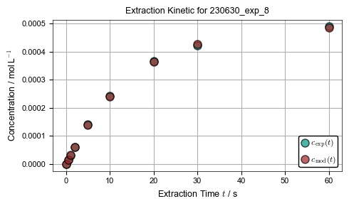

```python
from scipy.optimize import basinhopping

# Optimization function for a given extraction experiment
def opt_exp(folder, mod):
    # Import UV-VIS data and transform into experimental extraction kinetic
    t_exp, c_exp = imp_exp(folder, mod)

    # Optimize the cost function
    opt_res = basinhopping(cost_fun_extraction, x0=np.array([1,1]), niter=5,
                           minimizer_kwargs={'args':(c_exp, t_exp)})
    k_opt = opt_res.x[0]
    c_inf_opt = opt_res.x[1]

    # Re-calculate the optimized kinetic c_mod
    solution = solve_ivp(rhs_kinetic, t_span=(t_exp[0],max(t_exp)),
                         y0=np.array([c_exp[0],]), method='RK45',
                         t_eval=t_exp, args=(k_opt, c_inf_opt))
    c_mod = solution.y

    return k_opt, c_inf_opt, t_exp, c_exp, c_mod

folder = './data/exp_data/230630_exp_8/'
exp_name = folder.split('/')[-2]

# Import OLS model from chapter 7
lin_mod = np.load('./data/my_ols_model.npy', allow_pickle=True).item()

# Optimize the kinetic parameters!
k_opt, c_inf_opt, t, c_exp, c_mod = opt_exp(folder, lin_mod)

# Plot results and make pretty. Also print the optimized parameters
print(f'The optimized parameters for experiment {exp_name} are:')
print(f'k_opt = {k_opt:.2e} and c_inf_opt = {c_inf_opt:.2e}.')
fig, ax = plt.subplots(figsize=(5,3))
ax.scatter(t, c_exp, edgecolors='black', color=mp.green, label='$c_{\,\mathrm{exp}}(t)$', alpha=0.7)
ax.scatter(t, c_mod, edgecolors='black', color=mp.red, label='$c_{\,\mathrm{mod}}(t)$', alpha=0.7)
ax.set_ylabel('Concentration / mol$\,$L$^{-1}$')
ax.set_xlabel('Extraction Time $t$ / s')
ax.legend(loc='lower right', fontsize='small', framealpha=1, ncol=1, labelspacing = 0.6)
ax.grid(True)
ax.set_title(f'Extraction Kinetic for {exp_name}')
plt.tight_layout()
```

**Interim Summary**

Let's briefly recap: Fig. 1 shows the steps we have taken so far to get from a folder with experimental raw data (a single experiment) to the corresponding kinetic parameters.

[figure not shown]

**Figure 1:** *From experimental raw data to kinetic parameters.*

## 10.3 Generalizing the Results

Currently, we are able to *"extract"* kinetic parameters from any given experiment. Thinking back to the motivation, we were interested in finding a functional dependence between the kinetic rates (`k`, `c_inf`) and the relevant process parameters. As you can see, we performed 14 experiments (14 folders), each with a specific set of process parameters. We varied the grind size `x_50`, the temperature `T` and the water to coffee ratio `Vw`. The parameter settings are stored in `./data/extraction_doe.xlsx` and can be read into a parameter array `P` with `shape = (14,3)` (see chapter 5).

After optimizing all of these 14 experiments (this will take a while) we also have the desired kinetic rates and store them in an array `K` with `shape = (14,2)`.

```python
import pandas as pd

# Import parameter arrays from .xlsx
dataframe_excel = pd.read_excel('data/extraction_doe.xlsx', sheet_name=0,
                                skiprows=3, header=None)
P = dataframe_excel.iloc[:,1:].astype(float).values

# Optimize all 14 experiments
K = np.zeros((P.shape[0],2))
for e in range(P.shape[0]):
    print(f'Optimizing experiment no. {e+1}')
    folder = './data/exp_data/230630_exp_' + str(e+1) +'/'
    K[e,0], K[e,1], _, _, _ = opt_exp(folder, lin_mod)

# Save results (this took some time)
np.save('data/opt_res.npy',{'P':P, 'K':K})
```

```
Optimizing experiment no. 1
Optimizing experiment no. 2
Optimizing experiment no. 3
Optimizing experiment no. 4
Optimizing experiment no. 5
Optimizing experiment no. 6
Optimizing experiment no. 7
Optimizing experiment no. 8
Optimizing experiment no. 9
```

```
Optimizing experiment no. 10
Optimizing experiment no. 11
Optimizing experiment no. 12
Optimizing experiment no. 13
Optimizing experiment no. 14
```

This allows us to find a data-driven model `mpl_mod` that predicts `K` based on `P`, i.e. finds a functional dependence $\mathcal{K}=f(\mathcal{P})$. We'll use an MLP, similar to the methods introduced in chapter 8!

```python
from sklearn.preprocessing import StandardScaler
from sklearn.model_selection import train_test_split
from sklearn.neural_network import MLPRegressor
from sklearn.metrics import mean_squared_error

# Import the data
data = np.load('data/opt_res.npy', allow_pickle=True).item()
K, P = data['K'], data['P']

# Standardize data
K_tf = StandardScaler().fit(K)
P_tf = StandardScaler().fit(P)

K_scl = K_tf.transform(K)
P_scl = P_tf.transform(P)

# Test-Train split
K_train, K_test, P_train, P_test = \
    train_test_split(K_scl, P_scl, test_size=0.2, random_state=42)

# Train and save a multilayer perceptron
mlp_mod = MLPRegressor(hidden_layer_sizes=(100,100), activation='relu', solver='adam',
                       alpha=0.001, random_state=1, max_iter=5000, tol=1e-6)

mlp_mod.fit(P_train, K_train)

np.save('data/mlp_P_K.npy', {'mlp':mlp_mod, 'K_tf':K_tf, 'P_tf':P_tf})

# Evaluate and print model performance on test data
rmse = mean_squared_error(K_test, mlp_mod.predict(P_test), squared=False)
print(f'The RMSE on the test-data (for standardized outputs) is {rmse:.2f}.')
```

```
The RMSE on the test-data (for standardized outputs) is 0.09.
```

Unfortunately, it is quite difficult to visualize the predictions of this MLP because we have multiple inputs and outputs. However, this MLP model predicts the kinetic rates for **any** combination of process parameters, which we can later use to solve for the extraction kinetic in Eq. (1). Think about that for a second: we can predict any extraction kinetic, even for parameter combinations we did not measure! This means that we have obtained a **fully calibrated**, **data-driven model**! Let's put it to the test!

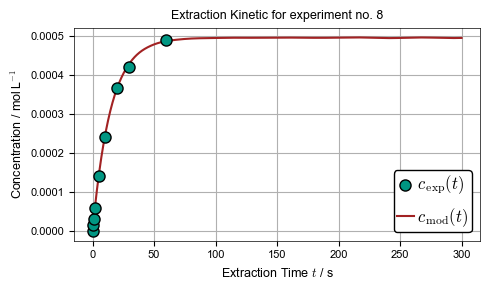

```python
# Predict the extraction kinetic based on P = [x50, Tm Vw]
def pred_ex(P, mod, K_tf, P_tf, c0=0, t0=0, t_end=300):
    # Predict k and c_inf
    P = P_tf.transform(np.array(P).reshape(1,-1))
    K = mod.predict(P)
    K = K_tf.inverse_transform(K)
    k, c_inf = K[0,0], K[0,1]

    # Solve the IVP
    solution = solve_ivp(rhs_kinetic, t_span=(t0,t_end),
                         y0=np.array([c0,]), method='RK45',
                         t_eval=np.linspace(t0, t_end, 1000), args=(k, c_inf))
    c_mod = solution.y[0,:]
    t_mod = solution.t

    return c_mod, t_mod

# Import MLP and transformer
data = np.load('data/mlp_P_K.npy', allow_pickle=True).item()
mlp_mod = data['mlp']
K_tf = data['K_tf']
P_tf = data['P_tf']

# Define process parameters. Use and experiment to check
exp_no = 8
dataframe_excel = pd.read_excel('data/extraction_doe.xlsx', sheet_name=0,
                                skiprows=3, header=None)
P = dataframe_excel.iloc[:,1:].astype(float).values
P_check = P[exp_no-1, :]
# Or define your own!
# P_check = [700, 25.8, 98.4] # Experiment 3, but 700µm instead of 354µm

# Predict the extraction kinetic
c_mod, t_mod = pred_ex(P_check, mlp_mod, K_tf, P_tf)

# Import experimental data
t_exp, c_exp = imp_exp('./data/exp_data/230630_exp_' + str(exp_no) +'/', lin_mod)

# Compare the results to exp_no
fig, ax = plt.subplots(figsize=(5,3))
ax.scatter(t_exp, c_exp, edgecolors='black', color=mp.green, label='$c_{\,\mathrm{exp}}(t)$', zorder=3)
ax.plot(t_mod, c_mod, color=mp.red, label='$c_{\,\mathrm{mod}}(t)$')
ax.set_ylabel('Concentration / mol$\,$L$^{-1}$')
ax.set_xlabel('Extraction Time $t$ / s')
ax.legend(loc='lower right', fontsize='large', framealpha=1, ncol=1, labelspacing = 0.6)
ax.grid(True)
ax.set_title(f'Extraction Kinetic for experiment no. {exp_no}')
plt.tight_layout()
```

## 10.4 Final Notes

Today, we have applied everything we have learned in this course to find a fully calibrated model for coffee extraction. The workflow is visualized in Fig. 2 and can be applied to virtually any other physical problem.

[figure not shown]

**Figure 2:** *Overview of the workflow of chapter 10.*

If you take away only one thing from this course, let it be this:

> *Physical (mechanistic) and empirical (data-driven) models are not two opposing or competing concepts. On the contrary: Physical models require experimental data for calibration because the necessary parameters are often unknown. On the other hand, purely data-driven approaches lack the desired transparency and are prone to overfitting. Today, we have unknowingly introduced so called* [***hybrid models***](https://doi.org/10.1016/j.compchemeng.2013.08.008)*, which retain the physical knowledge of the process (here Eq. 1), but perform certain subtasks (here the estimation of $k$ and $c_{\infty}$) data-driven.*

With everything you've learned, revisit the *"logo"* of this course shown in Fig. 3 and reflect on all the things you've learned and applied in this course.

[figure not shown]

**Figure 3:** *Data-driven modeling with Python.*